# CH08P50 Chi Square Test for Association

crl

April 3, 2018

```r
knitr::opts_chunk$set(echo = TRUE)
```

# QCI Six Sigma Primer

## Chi Square Test for Association (page VIII-50)

### Read More

The chi square test has several applications.

- To compare a sample variance against a known population variance.
- To compare goodness-of-fit of data to a distribution.
- To test for association between categorical variables with categorical (count) responses.

*This material addresses the chi square test for association.*

### More Resources

[Chi Square Test Wikipedia](https://en.wikipedia.org/wiki/Chi-squared_test)

[Presentation](https://docs.google.com/presentation/d/18VCccqgjbSC2qPQAtl97FmRiec6GXO_t9WwSkKcoiWA/edit?usp=sharing)

[Example](http://www.sthda.com/english/wiki/chi-square-test-of-independence-in-r)

# Analysis

## Load Packages

```r
library(tidyverse)
```

```r
library(gplots)
```

## Primer Example 8.18

Prepare the data set.

```r
(dat_radio <- read.csv("data/ch08p51-chi-square-test-tabular.csv", row.names = 1))
```

```
##       detected notdetected
## insp1       27           3
## insp2       25           5
## insp3       22           8
```

```r
# note that we set first column in the csv file as row names in the dataframe
```

### Now we perform the chi square test

alpha = 0.05

The question asks: “Is there a difference between the X-ray inspectors in detection?”

This is the **research hypothesis**.

The **null hypothesis** would then be the ‘status quo’

- aka ‘no difference’, or ‘no association found’

H0: There is no difference between the three inspectors. H0: p1 = p2 = p3  
HA: At least one of the proportions is different. H1: p1 <> p2 <> p3

The degrees of freedom = (rows - 1)(columns - 1) = (2-1)(3-1) = 2

Create a contingency table from the dataframe.

```r
(tbl_radio <- as.table(as.matrix(dat_radio)))
```

```
##       detected notdetected
## insp1       27           3
## insp2       25           5
## insp3       22           8
```

Look at the table.

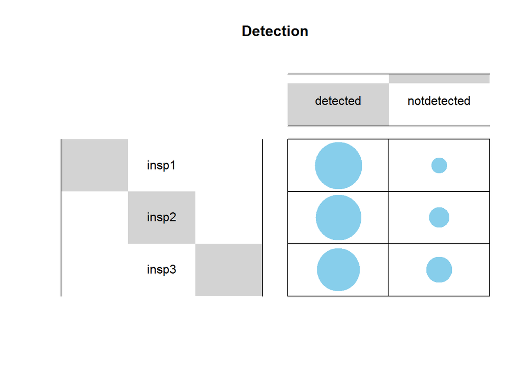

```r
balloonplot(t(tbl_radio), main = "Detection", xlab = "", ylab = "",
            label = FALSE, show.margins = FALSE)
```

With a one-sided hypothesis, we put all of alpha into one tail, which affects the critical value of chi square that defines the rejection region.

The critical value (one-sided) of X<sup>2</sup> with (r-1)(c-1) degrees of freedom.

```r
hypalpha <- 0.05
degf <- (nrow(tbl_radio) - 1) * (ncol(tbl_radio) - 1)
chisqcrit <- round(qchisq(p = hypalpha, df = degf, lower.tail = FALSE), 3)
cat(paste('Critical value (right tail) of chisq =', chisqcrit, 'with degrees of freedom =', degf))
```

```
## Critical value (right tail) of chisq = 5.991 with degrees of freedom = 2
```

Look at the p-value of the chi square test.

```r
(chisqcalc_out <- chisq.test(tbl_radio))
```

```
##
##  Pearson's Chi-squared test
##
## data:  tbl_radio
## X-squared = 2.8885, df = 2, p-value = 0.2359
```

```r
chisqcalc <- chisqcalc_out$statistic
```

We see that the p-value from the chi square test (0.2359) is greater than alpha (0.05).

- Therefore, we FAIL TO REJECT H0 (null hypothesis).
- There is not enough evidence to support the conclusion that there is a difference in the ability of inspectors to detect.

Drawing conclusions

```r
if (chisqcalc < chisqcrit){
  cat("chi square calculated is less than chi square critical therefore FAIL TO REJECT H0")
} else {
  cat("chi square calculated is greater than chisquare critical therefore REJECT H0")
}
```

```
## chi square calculated is less than chi square critical therefore FAIL TO REJECT H0
```

Graphical representation of chi square test result.

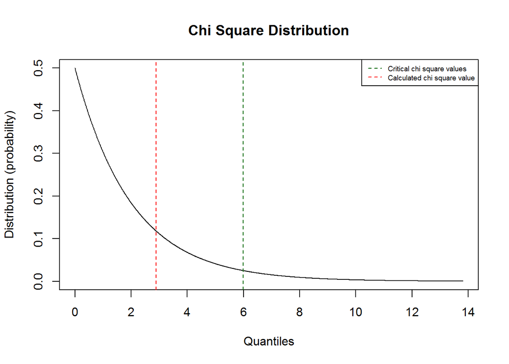

```r
# create a plot showing the outcome
xq <- seq(0, qchisq(p = 0.999, df = degf), by = 0.01)  # the 'quantiles' (x values)
xp <- dchisq(x = xq, df = degf)  # the distribution (y values)

plot(x = xq, y = xp, type = 'l',
     xlab = 'Quantiles', ylab = 'Distribution (probability)')
title(main = 'Chi Square Distribution')

# plots the critical t value based on degrees of freedom (df = sample size - 1)
abline(v = chisqcalc, lty = 2, col = 'red')

# plots the calculate t value
abline(v = chisqcrit, lty = 2, col = 'darkgreen')

# add a legend
legend("topright", legend=c("Critical chi square values", "Calculated chi square value"),
       col=c("darkgreen", "red"), lty = 2, cex=0.6)
```

### What does the chi-square density look like for different degrees of freedom?

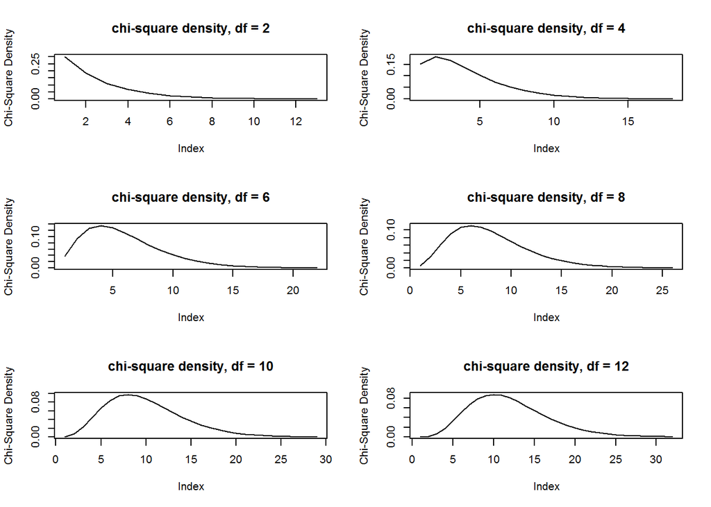

```r
layout(matrix(c(1,2,3,4,5,6), 3, 2, byrow = TRUE))
for (i in 1:6) plot(
  dchisq(1:qchisq(p = 0.999, df = i*2), i*2),
  main = paste("chi-square density, df =", i*2),
  ylab = 'Chi-Square Density',
  type = 'l')
```